# Generative AI Applications

- Student: Max Raxy
- Dataset: (https://www.kaggle.com/datasets/splcher/animefacedataset)

We are using **Anime Face Dataset** dataset from **Kaggle**. The dataset contains `63565` anime-face images, and the goal is to use Variational Auto-Encoder (VAE), to generate anime faces.

# Setup

## Import required modules

```python
from pathlib import Path
import time
import sys
SRC_DIR = str(Path.cwd().parent /'src')
if SRC_DIR not in sys.path:
    sys.path.append(SRC_DIR)

notebook_start_time = time.time() # Start the global timer

# if set to True full print(model) and summary(model, input_size=(settings.nn_batch_size, 1, 224, 224)) will be shown
SHOW_MODEL_DETAIL_INFO = False
```

```python
import importlib
from config import settings
import utils as ut #use importlib.reload(ut) if reload needed in specific cell during development
#import utils_ml as utml
import vae
import math
import random
import numpy as np
import pandas as pd
import seaborn as sns
import matplotlib # for version check
import matplotlib.pyplot as plt
from sklearn.metrics import confusion_matrix
import torch
from torchinfo import summary
import torch.nn as nn
from torch.utils.data import Dataset, DataLoader, Subset, random_split
import torchvision
from torchvision import datasets, transforms

from IPython.display import clear_output, display, Image
import warnings

pd.set_option('display.max_columns', None)
pd.set_option('display.max_colwidth', None)
# Enable high-resolution Retina plots
%config InlineBackend.figure_format = 'retina'
```

```python
print("*" * 75)
print(f'PYTHON VERSION:      {sys.version}')
print(f'PYTHON VPATH:        {sys.executable}')
print(f"Pandas version:      {pd.__version__}")
print(f"NumPy version:       {np.__version__}")
print(f"Matplotlib version:  {matplotlib.__version__}")
print(f"Seaborn version:     {sns.__version__}")
print("*" * 75)
```

```
PYTHON VERSION:      3.13.14 (main, Jul 23 2026, 14:44:45) [Clang 22.1.3 ]
PYTHON VPATH:        /home/max/x/zc05-gen-ai/.venv/bin/python
Pandas version:      3.0.5
NumPy version:       2.5.2
Matplotlib version:  3.11.1
Seaborn version:     0.13.2
```

```python
print(f'Torch version: {torch.__version__}')
print(f'CUDA available: {torch.cuda.is_available()}')
print(f'CUDA version used: {torch.version.cuda}')
```

```
Torch version: 2.13.0+cu130
CUDA available: True
CUDA version used: 13.0
```

```python
def seed_all(seed:int=42):
    """
    set random seed and cuda related settings for reproducibility
    Args:
        seed: int setting the seed
    Return:
        None
    """
    random.seed(seed)
    np.random.seed(seed)
    torch.manual_seed(seed)
    torch.cuda.manual_seed_all(seed)
    torch.backends.cudnn.deterministic = True
    torch.backends.cudnn.benchmark = False
#---------------------------------------------
seed_all(settings.RANDOM_SEED)
```

# Ingestion

## Download Dataset

- This function only download the dataset, if it is not downloaded yet!

```python
ut.download_dataset_from_kagglehub()
```

```
dataset is already downloaded in /home/max/x/zc05-gen-ai/data
```

## Check Dataset for any corrupted files or non-RGB images

```python
df_info, non_rgb_files, corrupted_files = ut.scan_images(settings.DATA_DIR/settings.DATASET_DIR, max_workers=8)
```

```
Found 63565 images. Starting scan...
Processed 10000 / 63565 files...
Processed 20000 / 63565 files...
Processed 30000 / 63565 files...
Processed 40000 / 63565 files...
Processed 50000 / 63565 files...
Processed 60000 / 63565 files...
Number of Corrupted or unreadable images: 0
Number of Non-RGB images: 0
```

# Exploratory Data Analysis (EDA)

```python
df_info.describe()
```

|  | width | height | aspect_ratio |
| --- | --- | --- | --- |
| count | 63565.000000 | 63565.000000 | 63565.000000 |
| mean | 89.594557 | 89.594289 | 1.000003 |
| std | 19.014631 | 19.014337 | 0.000171 |
| min | 25.000000 | 25.000000 | 1.000000 |
| 25% | 77.000000 | 77.000000 | 1.000000 |
| 50% | 91.000000 | 91.000000 | 1.000000 |
| 75% | 102.000000 | 102.000000 | 1.000000 |
| max | 220.000000 | 220.000000 | 1.019608 |

### Note

- Aspect Ratio is almost fixed to 1, with slight deviation from 1

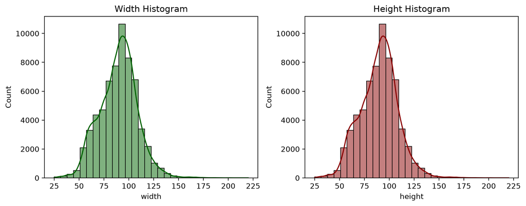

```python
fig, axs=plt.subplots(1,2,figsize=(10,4))
sns.histplot(data=df_info, x='width', kde=True, bins=30, color='darkgreen', ax=axs[0])
sns.histplot(data=df_info, x='height', kde=True, bins=30, color='darkred', ax=axs[1])
axs[0].set_title('Width Histogram')
axs[1].set_title('Height Histogram')
plt.tight_layout()
plt.savefig(settings.IMG_DIR/'hw-hist.png', dpi=600)
```

### Note

- Width and height with mean=89 (median = 91), nearly normal, and we need resizing for our Machine Learning
- We choose to use 64x64 (closer to minimum dimensions) so enlarging low resolution is not extreme, and the 64x64 is not too big for home-pc training

[figure not shown]

```python
ut.show_sample_images_in_grid(settings.DATA_DIR/settings.DATASET_DIR, target_size= (64, 64), figsize= (4, 4), num_images = 16, images_per_row= 4, padding= 2)
plt.title("Sample of Original Images")
plt.tight_layout()
plt.savefig(settings.IMG_DIR/'sample-img-org.png', dpi=600)
```

# ML

## Define all settings and parameters

```python
from dataclasses import dataclass, field, asdict, replace
@dataclass(frozen=True)
class DataConfig:
    batch_size:int = 64
    mean:tuple[float, float, float]= (0.5,0.5,0.5)
    std:tuple[float, float, float]= (0.5,0.5,0.5)
    latent_dim:int = 128 # embedding-dim
    n_epochs: int = 50*2
    show_every:int = 5*2 # show total-loss and sample generated image every K epoch
    image_size:int = 64
    device:torch.device = torch.device('cuda' if torch.cuda.is_available() else 'cpu')

    num_image_to_display_during_training: int = 16
    #print_every: int = 330 # during traininh print every K steps
    #----------------------
    #Loss function
    kld_weight:float = 0.00025 # VAE, KL Divergance weight in loss calculation
    # kld_weight_max: max extra increase above kld_weight: increase from kld_weight at epoch 1 to kld_weight_max+kld_weight at last epoch
    # kld_weight_total = kld_weight + kld_weight_max*(epoch/epoch_max)^P (P 3 to 5)
    kld_weight_max:float = 0.0001 # It was 0.0001 for 50 epoch make it 0.00025 for 100 epoch
    kld_weight_fixed:bool = False # if we use fixed kld_weight or increase to max as epoch increase
    reduction:str = 'mean' # MSE/KLD loss reduction method: mean or sum
    rec_loss_type:str = 'BCE' # Reconstruction Loss Type: BCE (only when pixels in [0,1]), MSE, L1, MSEL1
    #----------------------------
    #Optimizer
    lr:float = 0.005
    betas:tuple[float, float] = (0.9, 0.999)
    weight_decay: float = 0.0
    gamma = 0.95 # gamma value for ExponentialLR scheduler
    #--------------------------------
    # ConvBlock/DeconvBlock
    batch_norm:bool = False # whether to apply BatchNorm2D after Conv2D
    negative_slope:float = 0 # negative_slope of LeakyReLU (zero means ReLU), default for LeakyReLU is 1e-2
    #------------------------------
    # Encoder / Decoder(Generator)
    conv_dim: int = 64 # number of filters in first layer of Encoder
    num_conv_layer:int = 4 # number of conv/deconv layer in Encoder/Decoder
    last_activation_sigmoid:bool = True # sigmoid if True, otherwise Tanh (if transformed image is [0,1]-> Sigmoid, if [-1,1]-> Tanh
    #--------------------------------
    test_ratio:float = 0.1
    valid_ratio:float = 0.1
    #
    model_name:str = 'VAE_BCE100' #a name for model for tracking/visualization/saving
    best_model_param_path: Path = field(init=False) #settings.OUT_DIR/f'best_model_param_{model_name}.pth'
    last_model_param_path: Path = field(init=False) #settings.OUT_DIR/f'last_model_param_{model_name}.pth'
    training_history_path: Path = field(init=False) #settings.OUT_DIR/f'training_history_{model_name}.csv'
    generated_samples_path: Path = field(init=False) #settings.OUT_DIR/f'generated_samples_{model_name}.pkl'

    def __post_init__(self):
        object.__setattr__(self, 'best_model_param_path', settings.OUT_DIR / f'best_model_param_{self.model_name}.pth')
        object.__setattr__(self, 'last_model_param_path', settings.OUT_DIR / f'last_model_param_{self.model_name}.pth')
        object.__setattr__(self, 'training_history_path', settings.OUT_DIR / f'training_history_{self.model_name}.csv')
        object.__setattr__(self, 'generated_samples_path', settings.OUT_DIR / f'generated_samples_{self.model_name}.pkl')

#--------------------------------------------------
CFG = DataConfig()
```

## Load Training, Validation, and Testing Dataset

- Dataset split to train/valid/test, Then transform as shown below

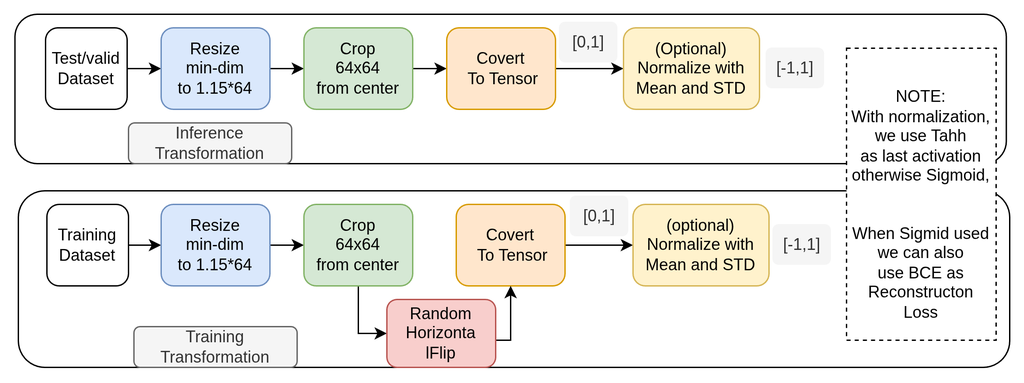

```python
display(Image(filename=settings.IMG_DIR/'vae-data-prep-blocks.drawio.png', width=800))
```

```python
dataloaders = vae.data.get_dataloaders(CFG)
```

```
train: 50853 (80.0%)
valid: 6356  (10.0%)
test : 6356  (10.0%)
```

[figure not shown]

```python
##Check few image from dataloader, using torchvision.utils.make_grid, normalize=True, convert -1,1 range to 0,1 for imshow
real_batch = next(iter(dataloaders['train']))
plt.figure(figsize=(4, 4))
plt.axis("off")
plt.title("Sample Training Images")
# Convert from (C, H, W) to (H, W, C) for matplotlib, using numpy transpose 1,2,0 or pytorch permute on grid tensor
# Cleanest version (if real_batch is still on CPU)
grid = torchvision.utils.make_grid(real_batch[0][:16], nrow=4, padding=2, normalize=True)
plt.imshow(grid.permute(1, 2, 0).numpy());
plt.tight_layout()
plt.savefig(settings.IMG_DIR/'sample-img-train.png', dpi=600)
```

# Define Variational Auto-Encoder (VAE) model

- VAE defined by Encoder and Decoder Block
- We use several layers of ConvBlock and DeConv Block
- The model with 4 layers of CovBlock (that we used as our final setup) shown below

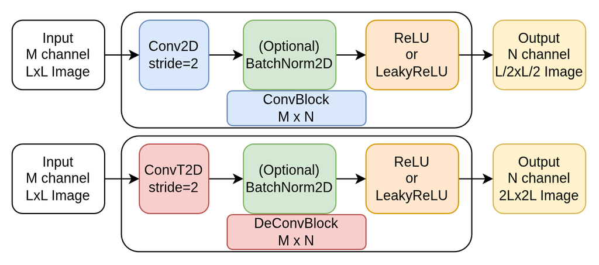

```python
display(Image(filename=settings.IMG_DIR/'vae-conv-deconv-blocks.drawio.png', width=800))
```

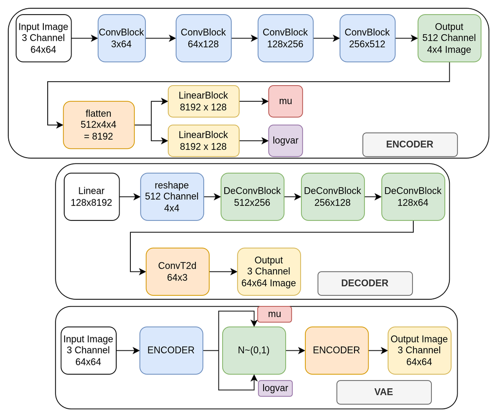

```python
display(Image(filename=settings.IMG_DIR/'vae-Enc-Dec.drawio.png', width=800))
```

```python
model=vae.model.VAE(CFG).to(CFG.device)
```

## Define Optimizer and Scheduler

```python
optimizer, scheduler= vae.optim.get_optimizer(model, CFG)
```

# Define the Loss function

In VAEs, the overall objective is to minimize the negative Evidence Lower Bound (ELBO):

$$\mathcal{L}_{\text{total}} = \mathcal{L}_{\text{rec}} + \beta \cdot \mathcal{L}_{\text{KLD}}$$

Here, the reconstruction loss measures how accurately the decoder reconstructs the input (e.g. using mean squared error), while the Kullback-Leibler Divergence ($\text{KLD}$) forces the latent space representation to approximate a standard normal distribution $\mathcal{N}(0, \mathbf{I})$.

$\beta$ is hyper-parameter, and we change it dynamically as **training progress**, initially low to let model adjust and reconstruct model, then increase to enforce the normal distribution

```python
loss_fn = vae.loss.vae_loss_function
```

## Train the model

|  | model | epoch | progress% | train_loss | train_recon_loss | train_kld_loss | train_kld_weight | valid_loss | valid_recon_loss | valid_kld_loss | valid_kld_weight |
| --- | --- | --- | --- | --- | --- | --- | --- | --- | --- | --- | --- |
| 0 | VAE_BCE100 | 1 | 1.0 | 0.588079 | 0.582954 | 20.498968 | 0.00025 | 0.566762 | 0.560439 | 25.293079 | 0.00025 |

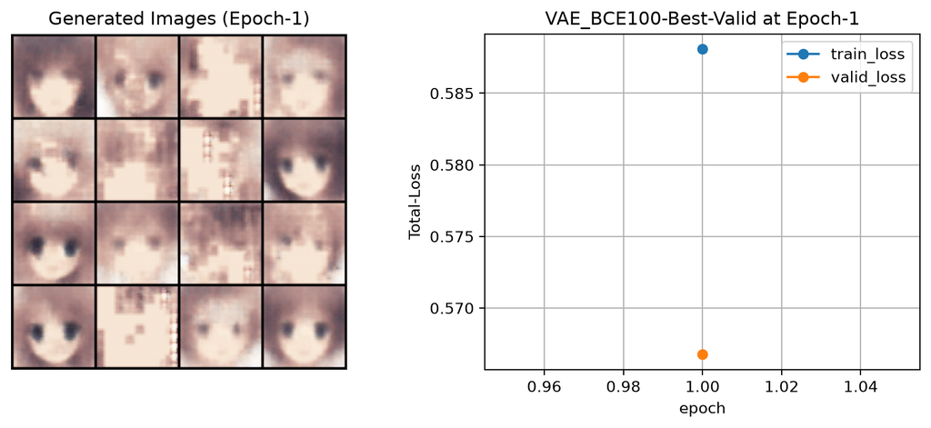

```
Epoch:02, Progress:2.0%, Total-Loss: Train= 0.561793, Valid= 0.555918
Epoch:03, Progress:3.0%, Total-Loss: Train= 0.553156, Valid= 0.551842
Epoch:04, Progress:4.0%, Total-Loss: Train= 0.549959, Valid= 0.550023
Epoch:05, Progress:5.0%, Total-Loss: Train= 0.548379, Valid= 0.547768
Epoch:06, Progress:6.0%, Total-Loss: Train= 0.547313, Valid= 0.547138
Epoch:07, Progress:7.0%, Total-Loss: Train= 0.546559, Valid= 0.546387
Epoch:08, Progress:8.0%, Total-Loss: Train= 0.546005, Valid= 0.545895
Epoch:09, Progress:9.0%, Total-Loss: Train= 0.545631, Valid= 0.545653
```

|  | model | epoch | progress% | train_loss | train_recon_loss | train_kld_loss | train_kld_weight | valid_loss | valid_recon_loss | valid_kld_loss | valid_kld_weight |
| --- | --- | --- | --- | --- | --- | --- | --- | --- | --- | --- | --- |
| 9 | VAE_BCE100 | 10 | 10.0 | 0.545238 | 0.534326 | 43.506057 | 0.000251 | 0.545743 | 0.534513 | 44.776589 | 0.000251 |

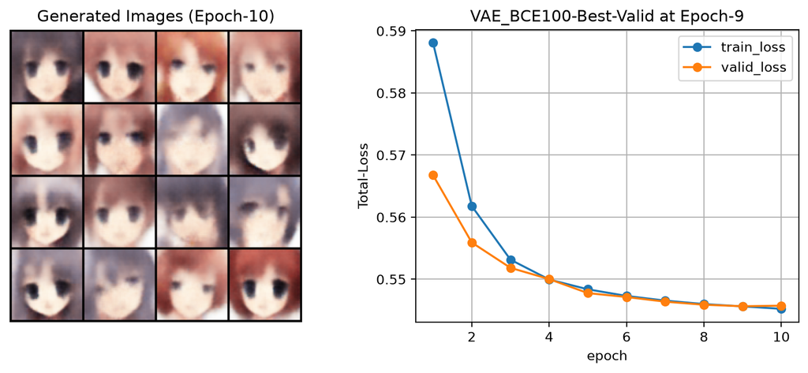

```
Epoch:11, Progress:11.0%, Total-Loss: Train= 0.544886, Valid= 0.544908
Epoch:12, Progress:12.0%, Total-Loss: Train= 0.544658, Valid= 0.544952
Epoch:13, Progress:13.0%, Total-Loss: Train= 0.544466, Valid= 0.544330
Epoch:14, Progress:14.0%, Total-Loss: Train= 0.544226, Valid= 0.544291
Epoch:15, Progress:15.0%, Total-Loss: Train= 0.544119, Valid= 0.543800
Epoch:16, Progress:16.0%, Total-Loss: Train= 0.543915, Valid= 0.543850
Epoch:17, Progress:17.0%, Total-Loss: Train= 0.543782, Valid= 0.544002
Epoch:18, Progress:18.0%, Total-Loss: Train= 0.543698, Valid= 0.543689
Epoch:19, Progress:19.0%, Total-Loss: Train= 0.543561, Valid= 0.543503
```

|  | model | epoch | progress% | train_loss | train_recon_loss | train_kld_loss | train_kld_weight | valid_loss | valid_recon_loss | valid_kld_loss | valid_kld_weight |
| --- | --- | --- | --- | --- | --- | --- | --- | --- | --- | --- | --- |
| 19 | VAE_BCE100 | 20 | 20.0 | 0.543361 | 0.531579 | 45.954069 | 0.000256 | 0.543886 | 0.531904 | 46.731405 | 0.000256 |

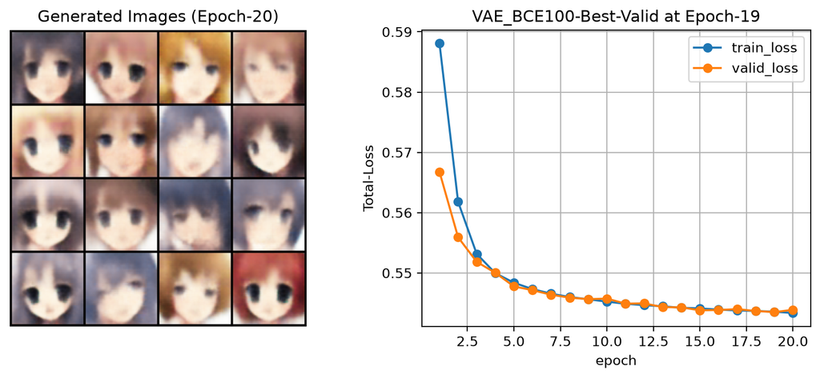

```
Epoch:21, Progress:21.0%, Total-Loss: Train= 0.543199, Valid= 0.543365
Epoch:22, Progress:22.0%, Total-Loss: Train= 0.543059, Valid= 0.543378
Epoch:23, Progress:23.0%, Total-Loss: Train= 0.542920, Valid= 0.542989
Epoch:24, Progress:24.0%, Total-Loss: Train= 0.542736, Valid= 0.542835
Epoch:25, Progress:25.0%, Total-Loss: Train= 0.542584, Valid= 0.542821
Epoch:26, Progress:26.0%, Total-Loss: Train= 0.542496, Valid= 0.542792
Epoch:27, Progress:27.0%, Total-Loss: Train= 0.542461, Valid= 0.542746
Epoch:28, Progress:28.0%, Total-Loss: Train= 0.542439, Valid= 0.543458
Epoch:29, Progress:29.0%, Total-Loss: Train= 0.542446, Valid= 0.543315
```

|  | model | epoch | progress% | train_loss | train_recon_loss | train_kld_loss | train_kld_weight | valid_loss | valid_recon_loss | valid_kld_loss | valid_kld_weight |
| --- | --- | --- | --- | --- | --- | --- | --- | --- | --- | --- | --- |
| 29 | VAE_BCE100 | 30 | 30.0 | 0.542445 | 0.529881 | 46.25647 | 0.000272 | 0.542771 | 0.530093 | 46.678213 | 0.000272 |

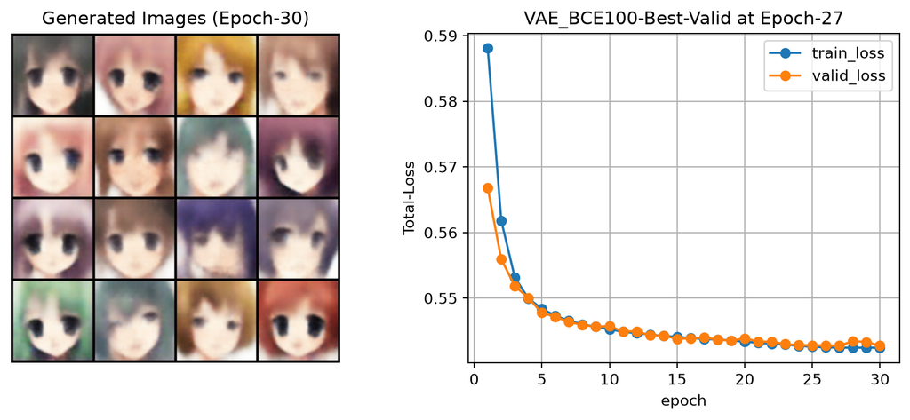

```
Epoch:31, Progress:31.0%, Total-Loss: Train= 0.548323, Valid= 0.548449
Epoch:32, Progress:32.0%, Total-Loss: Train= 0.552985, Valid= 0.553102
Epoch:33, Progress:33.0%, Total-Loss: Train= 0.556785, Valid= 0.556788
Epoch:34, Progress:34.0%, Total-Loss: Train= 0.559930, Valid= 0.560269
Epoch:35, Progress:35.0%, Total-Loss: Train= 0.562630, Valid= 0.562876
Epoch:36, Progress:36.0%, Total-Loss: Train= 0.564971, Valid= 0.565175
Epoch:37, Progress:37.0%, Total-Loss: Train= 0.566986, Valid= 0.567131
Epoch:38, Progress:38.0%, Total-Loss: Train= 0.568767, Valid= 0.568824
Epoch:39, Progress:39.0%, Total-Loss: Train= 0.570381, Valid= 0.570345
```

|  | model | epoch | progress% | train_loss | train_recon_loss | train_kld_loss | train_kld_weight | valid_loss | valid_recon_loss | valid_kld_loss | valid_kld_weight |
| --- | --- | --- | --- | --- | --- | --- | --- | --- | --- | --- | --- |
| 39 | VAE_BCE100 | 40 | 40.0 | 0.571734 | 0.553048 | 11.010293 | 0.001697 | 0.572188 | 0.55381 | 10.829204 | 0.001697 |

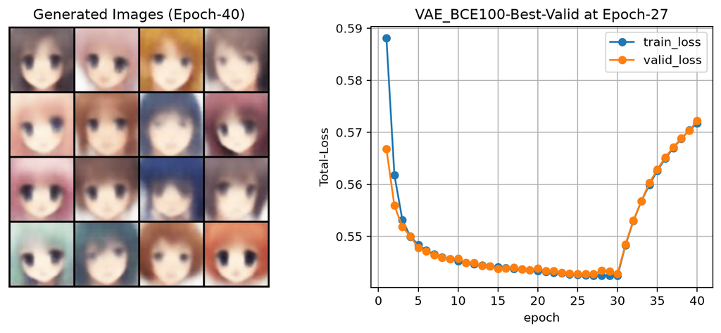

```
Epoch:41, Progress:41.0%, Total-Loss: Train= 0.573130, Valid= 0.573098
Epoch:42, Progress:42.0%, Total-Loss: Train= 0.574242, Valid= 0.574296
Epoch:43, Progress:43.0%, Total-Loss: Train= 0.575345, Valid= 0.575318
Epoch:44, Progress:44.0%, Total-Loss: Train= 0.576443, Valid= 0.576536
Epoch:45, Progress:45.0%, Total-Loss: Train= 0.577363, Valid= 0.577446
Epoch:46, Progress:46.0%, Total-Loss: Train= 0.578309, Valid= 0.578639
Epoch:47, Progress:47.0%, Total-Loss: Train= 0.579125, Valid= 0.579177
Epoch:48, Progress:48.0%, Total-Loss: Train= 0.579907, Valid= 0.579937
Epoch:49, Progress:49.0%, Total-Loss: Train= 0.580669, Valid= 0.580542
```

|  | model | epoch | progress% | train_loss | train_recon_loss | train_kld_loss | train_kld_weight | valid_loss | valid_recon_loss | valid_kld_loss | valid_kld_weight |
| --- | --- | --- | --- | --- | --- | --- | --- | --- | --- | --- | --- |
| 49 | VAE_BCE100 | 50 | 50.0 | 0.581367 | 0.564044 | 5.54778 | 0.003123 | 0.581425 | 0.563997 | 5.581 | 0.003123 |

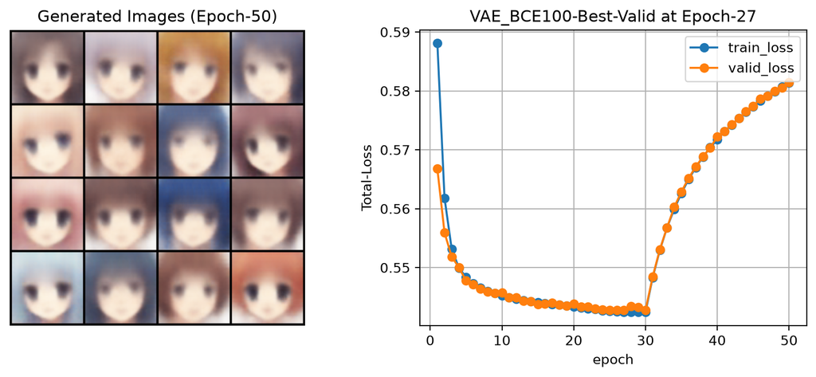

```
Epoch:51, Progress:51.0%, Total-Loss: Train= 0.582029, Valid= 0.582003
Epoch:52, Progress:52.0%, Total-Loss: Train= 0.582656, Valid= 0.582833
Epoch:53, Progress:53.0%, Total-Loss: Train= 0.583281, Valid= 0.583078
Epoch:54, Progress:54.0%, Total-Loss: Train= 0.583855, Valid= 0.584106
Epoch:55, Progress:55.0%, Total-Loss: Train= 0.584446, Valid= 0.584498
Epoch:56, Progress:56.0%, Total-Loss: Train= 0.584920, Valid= 0.585064
Epoch:57, Progress:57.0%, Total-Loss: Train= 0.585482, Valid= 0.585598
Epoch:58, Progress:58.0%, Total-Loss: Train= 0.585908, Valid= 0.586054
Epoch:59, Progress:59.0%, Total-Loss: Train= 0.586348, Valid= 0.585974
```

|  | model | epoch | progress% | train_loss | train_recon_loss | train_kld_loss | train_kld_weight | valid_loss | valid_recon_loss | valid_kld_loss | valid_kld_weight |
| --- | --- | --- | --- | --- | --- | --- | --- | --- | --- | --- | --- |
| 59 | VAE_BCE100 | 60 | 60.0 | 0.586899 | 0.57073 | 3.555278 | 0.004548 | 0.58703 | 0.57075 | 3.579669 | 0.004548 |

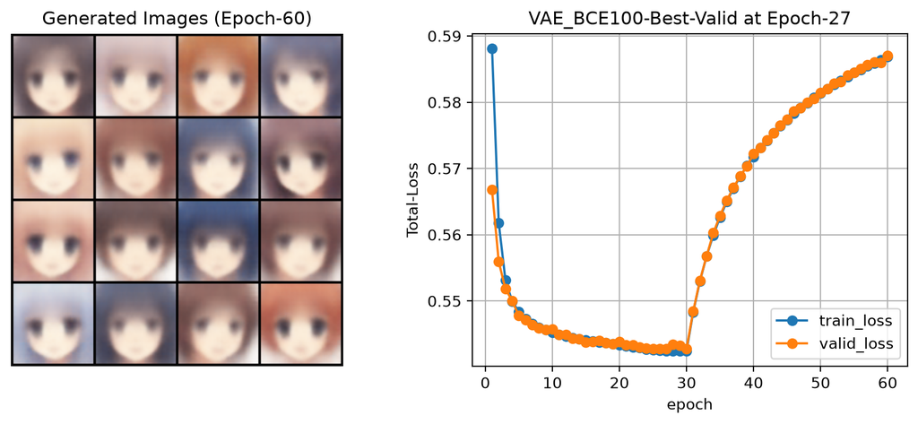

```
Epoch:61, Progress:61.0%, Total-Loss: Train= 0.587314, Valid= 0.587235
Epoch:62, Progress:62.0%, Total-Loss: Train= 0.587738, Valid= 0.587651
Epoch:63, Progress:63.0%, Total-Loss: Train= 0.588072, Valid= 0.588366
Epoch:64, Progress:64.0%, Total-Loss: Train= 0.588588, Valid= 0.588145
Epoch:65, Progress:65.0%, Total-Loss: Train= 0.588878, Valid= 0.588922
Epoch:66, Progress:66.0%, Total-Loss: Train= 0.589250, Valid= 0.589272
Epoch:67, Progress:67.0%, Total-Loss: Train= 0.589655, Valid= 0.589851
Epoch:68, Progress:68.0%, Total-Loss: Train= 0.590076, Valid= 0.589911
Epoch:69, Progress:69.0%, Total-Loss: Train= 0.590368, Valid= 0.590345
```

|  | model | epoch | progress% | train_loss | train_recon_loss | train_kld_loss | train_kld_weight | valid_loss | valid_recon_loss | valid_kld_loss | valid_kld_weight |
| --- | --- | --- | --- | --- | --- | --- | --- | --- | --- | --- | --- |
| 69 | VAE_BCE100 | 70 | 70.0 | 0.590707 | 0.575049 | 2.621443 | 0.005974 | 0.590659 | 0.574828 | 2.650095 | 0.005974 |

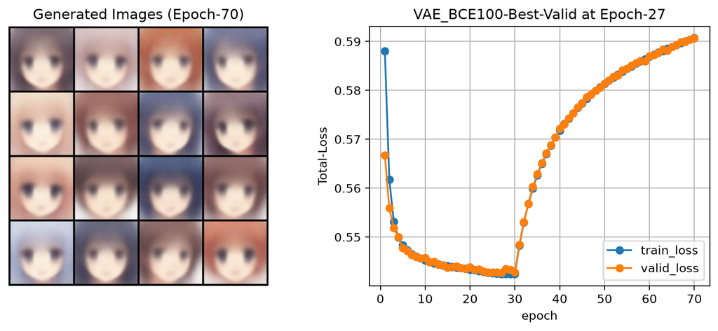

```
Epoch:71, Progress:71.0%, Total-Loss: Train= 0.591077, Valid= 0.590970
Epoch:72, Progress:72.0%, Total-Loss: Train= 0.591359, Valid= 0.591290
Epoch:73, Progress:73.0%, Total-Loss: Train= 0.591732, Valid= 0.591455
Epoch:74, Progress:74.0%, Total-Loss: Train= 0.592023, Valid= 0.591959
Epoch:75, Progress:75.0%, Total-Loss: Train= 0.592374, Valid= 0.592249
Epoch:76, Progress:76.0%, Total-Loss: Train= 0.592696, Valid= 0.592513
Epoch:77, Progress:77.0%, Total-Loss: Train= 0.592938, Valid= 0.593067
Epoch:78, Progress:78.0%, Total-Loss: Train= 0.593227, Valid= 0.592946
Epoch:79, Progress:79.0%, Total-Loss: Train= 0.593552, Valid= 0.593239
```

|  | model | epoch | progress% | train_loss | train_recon_loss | train_kld_loss | train_kld_weight | valid_loss | valid_recon_loss | valid_kld_loss | valid_kld_weight |
| --- | --- | --- | --- | --- | --- | --- | --- | --- | --- | --- | --- |
| 79 | VAE_BCE100 | 80 | 80.0 | 0.59385 | 0.578451 | 2.081307 | 0.007399 | 0.593893 | 0.578274 | 2.110936 | 0.007399 |

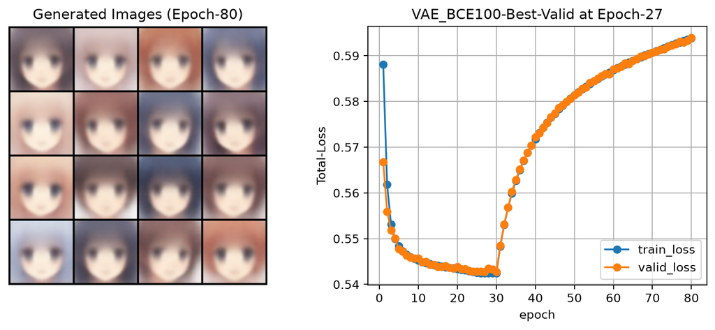

```
Epoch:81, Progress:81.0%, Total-Loss: Train= 0.594087, Valid= 0.593975
Epoch:82, Progress:82.0%, Total-Loss: Train= 0.594302, Valid= 0.594397
Epoch:83, Progress:83.0%, Total-Loss: Train= 0.594674, Valid= 0.594494
Epoch:84, Progress:84.0%, Total-Loss: Train= 0.594813, Valid= 0.594694
Epoch:85, Progress:85.0%, Total-Loss: Train= 0.595077, Valid= 0.595000
Epoch:86, Progress:86.0%, Total-Loss: Train= 0.595353, Valid= 0.595410
Epoch:87, Progress:87.0%, Total-Loss: Train= 0.595584, Valid= 0.595520
Epoch:88, Progress:88.0%, Total-Loss: Train= 0.595794, Valid= 0.595963
Epoch:89, Progress:89.0%, Total-Loss: Train= 0.596015, Valid= 0.596283
```

|  | model | epoch | progress% | train_loss | train_recon_loss | train_kld_loss | train_kld_weight | valid_loss | valid_recon_loss | valid_kld_loss | valid_kld_weight |
| --- | --- | --- | --- | --- | --- | --- | --- | --- | --- | --- | --- |
| 89 | VAE_BCE100 | 90 | 90.0 | 0.596319 | 0.581334 | 1.697974 | 0.008825 | 0.596279 | 0.581206 | 1.708124 | 0.008825 |

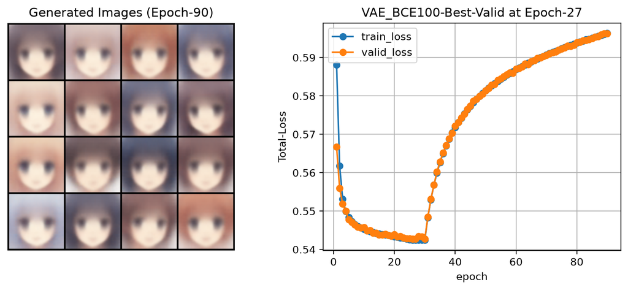

```
Epoch:91, Progress:91.0%, Total-Loss: Train= 0.596523, Valid= 0.596457
Epoch:92, Progress:92.0%, Total-Loss: Train= 0.596694, Valid= 0.596475
Epoch:93, Progress:93.0%, Total-Loss: Train= 0.596984, Valid= 0.596846
Epoch:94, Progress:94.0%, Total-Loss: Train= 0.597144, Valid= 0.597209
Epoch:95, Progress:95.0%, Total-Loss: Train= 0.597402, Valid= 0.597251
Epoch:96, Progress:96.0%, Total-Loss: Train= 0.597499, Valid= 0.597456
Epoch:97, Progress:97.0%, Total-Loss: Train= 0.597833, Valid= 0.597516
Epoch:98, Progress:98.0%, Total-Loss: Train= 0.597918, Valid= 0.597932
Epoch:99, Progress:99.0%, Total-Loss: Train= 0.598131, Valid= 0.598091
```

|  | model | epoch | progress% | train_loss | train_recon_loss | train_kld_loss | train_kld_weight | valid_loss | valid_recon_loss | valid_kld_loss | valid_kld_weight |
| --- | --- | --- | --- | --- | --- | --- | --- | --- | --- | --- | --- |
| 99 | VAE_BCE100 | 100 | 100.0 | 0.598341 | 0.583898 | 1.409137 | 0.01025 | 0.598269 | 0.583683 | 1.42304 | 0.01025 |

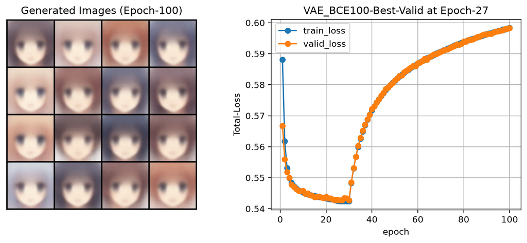

```
Best Validation Total Loss =0.542746 at Epoch 27
```

```python
#model is the last model, not necessary the best-model, load model with best/min validation loss using saved checkpoint
model, history_df, fig, valid_loss_min_epoch = vae.train.train_model(model,
                                               dataloaders,
                                               loss_fn,
                                               optimizer,
                                               scheduler,
                                               CFG,
                                               jupyter_vis=True)
if fig is not None: fig.savefig(settings.IMG_DIR/f'last-epoch-training-{CFG.model_name}.png', dpi=600)
```

## Check Learning curves

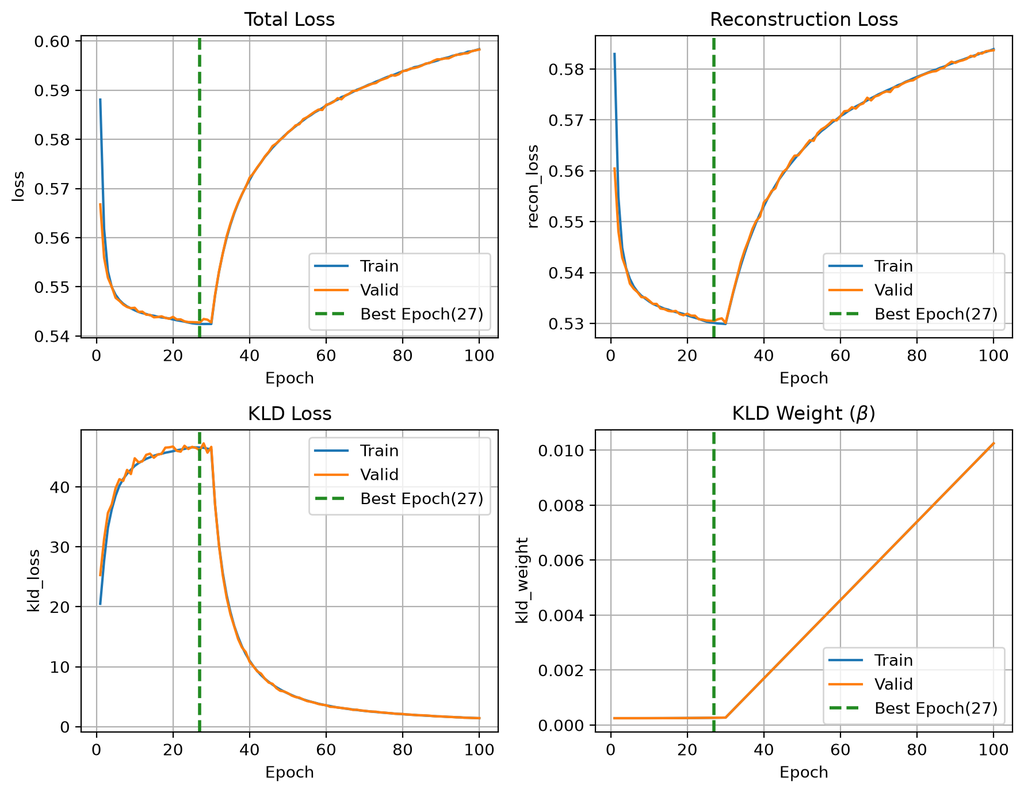

```python
fig, axes = plt.subplots(2, 2, figsize=(9, 7))
metrics = [
    ('loss', 'Total Loss'),
    ('recon_loss', 'Reconstruction Loss'),
    ('kld_loss', 'KLD Loss'),
    ('kld_weight', r'KLD Weight ($\beta$)')
]

for ax, (metric, title) in zip(axes.flatten(), metrics):
    sns.lineplot(data=history_df, x='epoch', y=f'train_{metric}', label=f'Train', ax=ax)
    sns.lineplot(data=history_df, x='epoch', y=f'valid_{metric}', label=f'Valid', ax=ax)
    ax.axvline(x=valid_loss_min_epoch, color="forestgreen", linestyle="--", linewidth=2, label=f"Best Epoch({valid_loss_min_epoch})")
    #ax.set_yscale('log')
    ax.set_title(title)
    ax.set_xlabel('Epoch')
    ax.set_ylabel(metric)
    ax.legend()
    ax.grid()

plt.tight_layout()
plt.savefig(settings.IMG_DIR/'learning-curve.png', dpi=600)
```

### Generated samples during Training: best vs last-epoch model (mode averaging (blurriness))

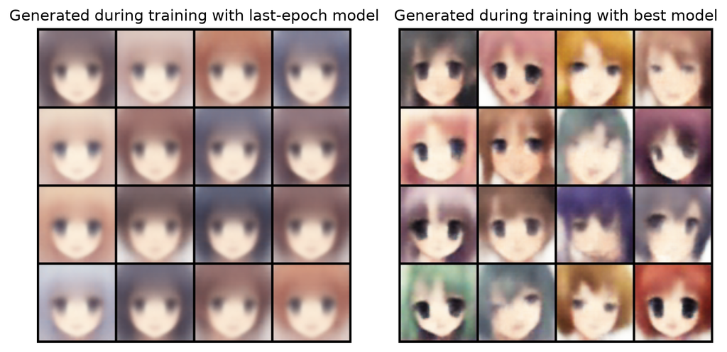

```python
import pickle as pkl
with open(CFG.generated_samples_path, 'rb') as f:
    loaded_samples = pkl.load(f)
last_img = loaded_samples[-1]
best_img = loaded_samples[valid_loss_min_epoch-1]
last_grid = torchvision.utils.make_grid(loaded_samples[-1], nrow=4, padding=2, normalize=True, value_range=(0, 1))
best_grid = torchvision.utils.make_grid(loaded_samples[valid_loss_min_epoch-1], nrow=4, padding=2, normalize=True, value_range=(0, 1))

fig, axs = plt.subplots(1, 2, figsize=(8, 4))

axs[0].imshow(last_grid.permute(1, 2, 0).detach().cpu().numpy())
axs[0].set_title(f"Generated during training with last-epoch model")
axs[0].axis('off')

axs[1].imshow(best_grid.permute(1, 2, 0).detach().cpu().numpy())
axs[1].set_title(f"Generated during training with best model")
axs[1].axis('off')
plt.tight_layout(rect=[0, 0, 1, 0.95])
plt.savefig(settings.IMG_DIR/'generated-during-training.png', dpi=600)
```

### Note

- while in epoch 27 we have our best model and generated images looks diverse (right image)
- the last-epoch model have min-KLD-loss but all generated sample looks almost similar (left model: mode averaging (blurriness))
- Therefore minimizing KLD-loss dose not necessary generate better samples,
- Decreasing or keep KLD-loss limited below some threshold will be a practical choice.

## Loading Best Model

- We continue with loading best model
- best model was saved during trainging at min total-loss for validation

```python
state_dict = torch.load(CFG.best_model_param_path, weights_only=True, map_location=CFG.device)
model.load_state_dict(state_dict);
```

# Check Loss Distribution

```python
#loss_fn = vae.loss.vae_loss_function
# NOTE: in  eval_model_on_dataset we use reduction=none to get loss per image
# epoch = valid_loss_min_epoch for best model, and CFG.n_epochs for last model
total_loss_test, recon_loss_test, kld_loss_test = vae.train.eval_model_on_dataset(model,dataloaders['test'],loss_fn,CFG,valid_loss_min_epoch)
total_loss_valid, recon_loss_valid, kld_loss_valid = vae.train.eval_model_on_dataset(model,dataloaders['valid'],loss_fn,CFG,valid_loss_min_epoch)
total_loss_train, recon_loss_train, kld_loss_train = vae.train.eval_model_on_dataset(model,dataloaders['train'],loss_fn,CFG,valid_loss_min_epoch)
```

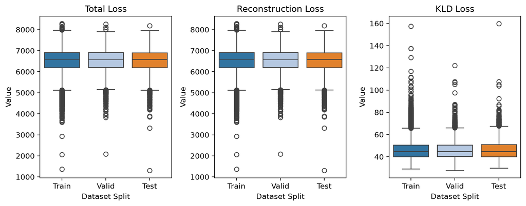

```python
# Helper function to combine arrays of different lengths into a tidy DataFrame
function_to_tidy = lambda train, valid, test, name: pd.concat([
    pd.DataFrame({name: train, 'Split': 'Train'}),
    pd.DataFrame({name: valid, 'Split': 'Valid'}),
    pd.DataFrame({name: test, 'Split': 'Test'})
], ignore_index=True)

df_total = function_to_tidy(total_loss_train, total_loss_valid, total_loss_test, 'Loss')
df_recon = function_to_tidy(recon_loss_train, recon_loss_valid, recon_loss_test, 'Loss')
df_kld = function_to_tidy(kld_loss_train, kld_loss_valid, kld_loss_test, 'Loss')

fig, axes = plt.subplots(1, 3, figsize=(10, 4))

plots_info = [
    (df_total, 'Total Loss'),
    (df_recon, 'Reconstruction Loss'),
    (df_kld, 'KLD Loss')
]

for ax, (df, title) in zip(axes, plots_info):
    sns.boxplot(data=df, x='Split', y='Loss', hue='Split',ax=ax, palette='tab20', legend=False)
    ax.set_title(title)
    ax.set_xlabel('Dataset Split')
    ax.set_ylabel('Value')

plt.tight_layout()
plt.savefig(settings.IMG_DIR/'loss-boxplot-per-split.png', dpi=600)
```

### Note

- In the above boxplot, `vae.train.eval_model_on_dataset` function internally used none for reduction i loss calculation, so we have loss per image, not sum/mean per batch, This way we can find the image with worst loss for later inspection.
- While there are some outliers, Overall the average (median) for Total-Loss, Reconstruction-Loss, and KLD-Loss, are similar per Split
- The overall distribution (e.g. IQR range) are also similar

## Extract latent representations (mu) from the test-dataset

```python
latent_list = []
model.eval()
with torch.no_grad():
    for real_images, _ in dataloaders['test']:
        real_images = real_images.to(CFG.device)
        _, mu, _ = model(real_images)
        latent_list.append(mu.detach().cpu())

latent_vectors = torch.cat(latent_list, dim=0).numpy()
print(f'collected latent-vector shape= {latent_vectors.shape}') # Shape: (N=test-dataset-len=6356, latent_dim-128)
```

```
collected latent-vector shape= (6356, 128)
```

## Check distribution of few latents

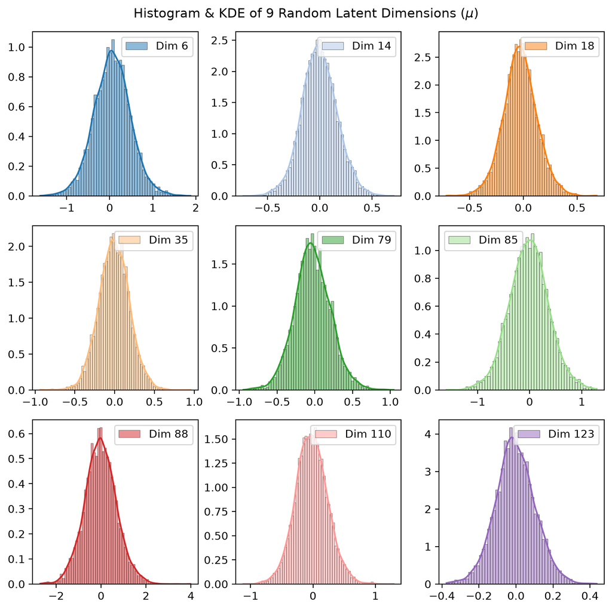

```python
# Randomly select N=9 indices from the total latent dimensions
N=9 # if changed other plot adjustment may be needed
latent_dim = latent_vectors.shape[1]
num_samples = min(N, latent_dim)
selected_dims = np.random.choice(latent_dim, num_samples, replace=False)
selected_dims.sort()  # sort for cleaner layout
palette = sns.color_palette("tab20", n_colors=N) #palette = sns.color_palette("pastel", n_colors=N)
fig, axes = plt.subplots(3, 3, figsize=(8, 8))
axes = axes.flatten()
for i, dim_idx in enumerate(selected_dims):
    sns.histplot(latent_vectors[:, dim_idx], ax=axes[i], kde=True, stat="density", color=palette[i], label=f'Dim {dim_idx}')
    axes[i].set_title("")
    axes[i].set_xlabel("")
    axes[i].set_ylabel("")
    axes[i].legend()

# Hide unused subplots if latent_dim is less than 9
for j in range(num_samples, len(axes)):
    axes[j].set_visible(False)

plt.suptitle(fr"Histogram & KDE of {N} Random Latent Dimensions ($\mu$)") #, y=1.01, fontsize=12)
plt.tight_layout()
plt.savefig(settings.IMG_DIR/'latent-density.png', dpi=600)
```

### Note

- Visually these randomly selected latent-vector are pretty close to normal distribution

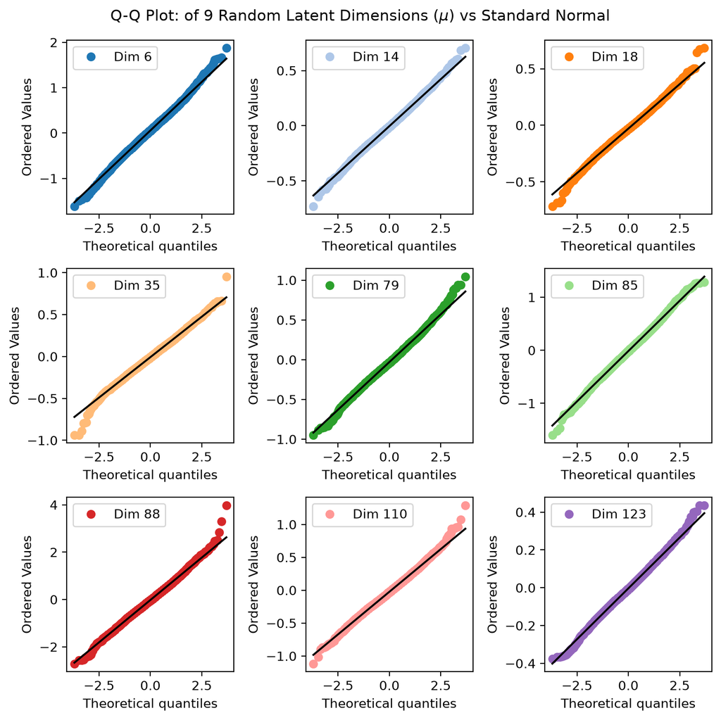

```python
import scipy.stats as stats
fig, axes = plt.subplots(3, 3, figsize=(8, 8))
axes = axes.flatten()
for i, dim_idx in enumerate(selected_dims):
    stats.probplot(latent_vectors[:, dim_idx], dist="norm", plot=axes[i])
    axes[i].set_title("")
    axes[i].get_lines()[0].set_color(palette[i])
    axes[i].get_lines()[0].set_markerfacecolor(palette[i])
    axes[i].get_lines()[1].set_color("black") # or another color
    axes[i].get_lines()[0].set_label(f'Dim {dim_idx}')
    axes[i].legend()

# Hide unused subplots if latent_dim is less than 9
for j in range(num_samples, len(axes)):
    axes[j].set_visible(False)

plt.suptitle(fr"Q-Q Plot: of {N} Random Latent Dimensions ($\mu$) vs Standard Normal") #, y=1.01, fontsize=12)
plt.tight_layout()
plt.savefig(settings.IMG_DIR/'latent-qqplot.png', dpi=600)
```

### Note

- The Q-Q plot shows strong alignment with the normal distribution in the central region, but exhibits some departure at one end or both end.
- This indicates that the latent dimension has more extreme values or outliers than a standard normal distribution would predict.

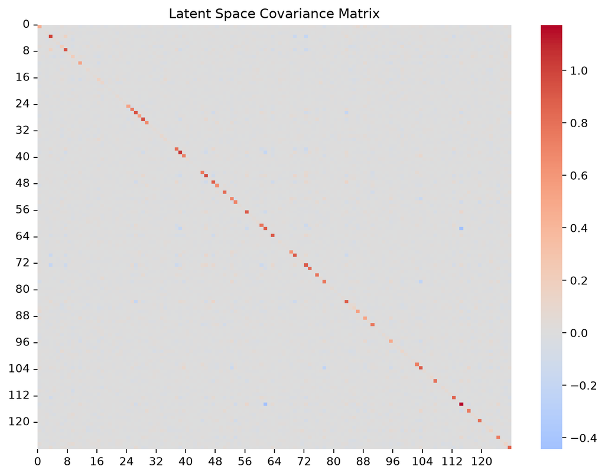

```python
# Compute covariance matrix of all latent dimensions
cov_matrix = np.cov(latent_vectors, rowvar=False) # row=observation, and columns are features=latent

# Visualize covariance heatmap (should look close to an identity matrix: diagonal ~1, off-diagonal ~0)
plt.figure(figsize=(8, 6))
sns.heatmap(cov_matrix, cmap='coolwarm', center=0)
# Set ticks every 8 or 16 steps
tick_positions = range(0, cov_matrix.shape[0], 8)
plt.xticks(ticks=tick_positions, labels=tick_positions, rotation=0)
plt.yticks(ticks=tick_positions, labels=tick_positions, rotation=0)
plt.title("Latent Space Covariance Matrix")
plt.tight_layout()
plt.savefig(settings.IMG_DIR/'latent-corr-mat.png', dpi=600)
```

### Note

- The ideal correlation between latent vectors will be identity matrix
- The above correlationis is mostly on main diagonal, but still there are some scatters light blue dot off-diagonal

## Top-4 Failed (Worst) Reconstruction and Top-4 Best Reconstruction

We select images with

- Top 4 min total-loss as images with best error/loss in reconstruction
- Top 4 max total-loss as images with worst error/loss in reconstruction
- Check them visually

[figure not shown]

```python
# Get top 4 lowest and top 4 highest loss indices using NumPy argsort
sorted_indices = np.argsort(total_loss_test)
best_indices = sorted_indices[:4]   # Top 4 min loss
worst_indices = sorted_indices[-4:] # Top 4 max loss

# Retrieve the real samples for top-4 best and top-4 worst
best_real = vae.data.get_images_by_indices(best_indices, dataloader=dataloaders['test'], batch_size=CFG.batch_size)
worst_real = vae.data.get_images_by_indices(worst_indices, dataloader=dataloaders['test'], batch_size=CFG.batch_size)

best_real = best_real.to(CFG.device)
worst_real = worst_real.to(CFG.device)

# Pass through the model to get reconstructions
model.eval()
with torch.no_grad():
    best_recon, _, _ = model(best_real)
    worst_recon, _, _ = model(worst_real)

# Setup 2x2 Grid Subplots (Top row: Best, Bottom row: Worst)
fig, axs = plt.subplots(2, 2, figsize=(6, 6))

# Make grid for best (Real vs Recon)
grid_best_real = torchvision.utils.make_grid(best_real, nrow=2, padding=2, normalize=True, value_range=(0, 1))
grid_best_recon = torchvision.utils.make_grid(best_recon, nrow=2, padding=2, normalize=True, value_range=(0, 1))

# Make grid for worst (Real vs Recon)
grid_worst_real = torchvision.utils.make_grid(worst_real, nrow=2, padding=2, normalize=True, value_range=(0, 1))
grid_worst_recon = torchvision.utils.make_grid(worst_recon, nrow=2, padding=2, normalize=True, value_range=(0, 1))

# Top Row: Best Loss (Real & Reconstructed)
axs[0, 0].imshow(grid_best_real.permute(1, 2, 0).detach().cpu().numpy(), vmin=0.0, vmax=1.0)
axs[0, 0].set_title("Top-4 Best Loss (Original)")
axs[0, 0].axis('off')

axs[0, 1].imshow(grid_best_recon.permute(1, 2, 0).detach().cpu().numpy(), vmin=0.0, vmax=1.0)
axs[0, 1].set_title("Top-4 Best Loss (Reconstructed)")
axs[0, 1].axis('off')

# Bottom Row: Worst Loss (Real & Reconstructed)
axs[1, 0].imshow(grid_worst_real.permute(1, 2, 0).detach().cpu().numpy(), vmin=0.0, vmax=1.0)
axs[1, 0].set_title("Top-4 Worst Loss (Original)")
axs[1, 0].axis('off')

axs[1, 1].imshow(grid_worst_recon.permute(1, 2, 0).detach().cpu().numpy(), vmin=0.0, vmax=1.0)
axs[1, 1].set_title("Top-4 Worst Loss (Reconstructed)")
axs[1, 1].axis('off')

plt.tight_layout()
#del best_real, worst_real, best_recon, worst_recon
plt.savefig(settings.IMG_DIR/'top4-best-worst.png', dpi=600)
```

### Note:

- Interestingly the top 4 images with best reconstruction loss are not a good quality images, even one of them is totally invalid (almost all black) images
- While reconstructed images in VAE is not sharp, but they are generally smooth (sometimes too smooth), but in the worst case here, the image is not smooth at all especially on the face looks like chessboard pattern (In the lower-right image the face is not recognizable at all)

[figure not shown]

```python
torch.cuda.empty_cache()
len_test_dataset = len(dataloaders['test'].dataset)
n= 16 # Number of samples to select
random_ints = np.random.randint(0, len_test_dataset, size=n)
nrow = 4        # Number of images per row in the grid
real_samples = vae.data.get_images_by_indices(random_ints, dataloader=dataloaders['test'], batch_size=CFG.batch_size)

with torch.no_grad():
    real_samples = real_samples.to(CFG.device)
    model.eval() # Ensure model is in eval mode

    #Get reconstructions from the CURRENT (last-epoch) model weights
    state_dict = torch.load(CFG.last_model_param_path, weights_only=True, map_location=CFG.device)
    model.load_state_dict(state_dict)
    recon_samples_last, _, _ = model(real_samples)

    #load the best-validation model weights
    state_dict = torch.load(CFG.best_model_param_path, weights_only=True, map_location=CFG.device)
    model.load_state_dict(state_dict)
    recon_samples_best, _, _ = model(real_samples)

grid_real = torchvision.utils.make_grid(real_samples, nrow=nrow, padding=2, normalize=True, value_range=(0, 1))
grid_recon_last = torchvision.utils.make_grid(recon_samples_last, nrow=nrow, padding=2, normalize=True, value_range=(0, 1))
grid_recon_best = torchvision.utils.make_grid(recon_samples_best, nrow=nrow, padding=2, normalize=True, value_range=(0, 1))

fig, axs = plt.subplots(1, 3, figsize=(12, 4))

axs[0].imshow(grid_real.permute(1, 2, 0).detach().cpu().numpy(), vmin=0.0, vmax=1.0)
axs[0].set_title(f"Original Images ({n}-Sample)")
axs[0].axis('off')

axs[1].imshow(grid_recon_last.permute(1, 2, 0).detach().cpu().numpy(), vmin=0.0, vmax=1.0)
axs[1].set_title(f"Recon with last-epoch model")
axs[1].axis('off')

axs[2].imshow(grid_recon_best.permute(1, 2, 0).detach().cpu().numpy(), vmin=0.0, vmax=1.0)
axs[2].set_title(f"Recon with best model")
axs[2].axis('off')

plt.tight_layout(rect=[0, 0, 1, 0.95])
plt.savefig(settings.IMG_DIR/'recon-last-best.png', dpi=600)
```

```python
filtered_df = history_df[history_df['epoch'].isin([valid_loss_min_epoch, CFG.n_epochs])]
filtered_df
```

|  | model | epoch | progress% | train_loss | train_recon_loss | train_kld_loss | train_kld_weight | valid_loss | valid_recon_loss | valid_kld_loss | valid_kld_weight |
| --- | --- | --- | --- | --- | --- | --- | --- | --- | --- | --- | --- |
| 26 | VAE_BCE100 | 27 | 27.0 | 0.542461 | 0.530084 | 46.574592 | 0.000266 | 0.542746 | 0.530492 | 46.113884 | 0.000266 |
| 99 | VAE_BCE100 | 100 | 100.0 | 0.598341 | 0.583898 | 1.409137 | 0.010250 | 0.598269 | 0.583683 | 1.423040 | 0.010250 |

### Note

- best model(epoch-27) has best validation total-loss (0.542746 vs 0.598269)
- last model (epoch-100) has better validation kld-loss (1.423040 vs 46.113884)
- The last model reconstructed image are mostly similar to each other since aggressively minimizing the KLD-loss (for demonstration purpose), affect and increase the construction loss as we can see.

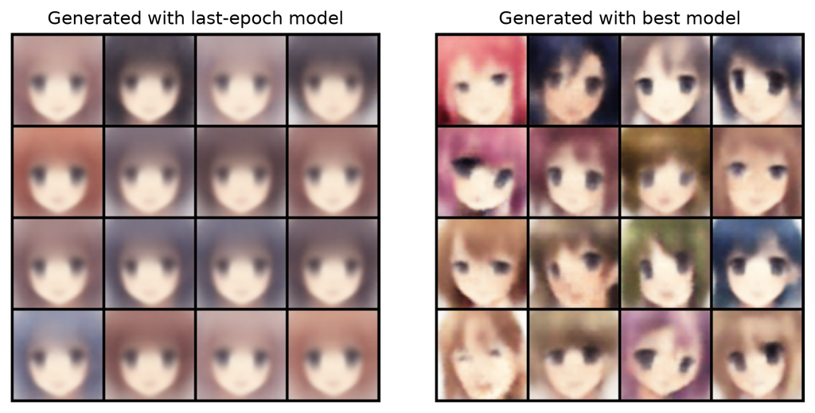

```python
n =16
# Generate random latent vectors from the standard normal prior
fixed_z = torch.randn(n, CFG.latent_dim).to(CFG.device) # batch of n

model.eval()
with torch.no_grad():
    state_dict = torch.load(CFG.last_model_param_path, weights_only=True, map_location=CFG.device)
    model.load_state_dict(state_dict)
    generated_images_last = model.decoder(fixed_z)

    state_dict = torch.load(CFG.best_model_param_path, weights_only=True, map_location=CFG.device)
    model.load_state_dict(state_dict)
    generated_images_best = model.decoder(fixed_z)

grid_gen_last = torchvision.utils.make_grid(generated_images_last, nrow=nrow, padding=2, normalize=True, value_range=(0, 1))
grid_gen_best = torchvision.utils.make_grid(generated_images_best, nrow=nrow, padding=2, normalize=True, value_range=(0, 1))

fig, axs = plt.subplots(1, 2, figsize=(8, 4))

axs[0].imshow(grid_gen_last.permute(1, 2, 0).detach().cpu().numpy())
axs[0].set_title(f"Generated with last-epoch model")
axs[0].axis('off')

axs[1].imshow(grid_gen_best.permute(1, 2, 0).detach().cpu().numpy())
axs[1].set_title(f"Generated with best model")
axs[1].axis('off')
plt.tight_layout(rect=[0, 0, 1, 0.95])
plt.savefig(settings.IMG_DIR/'randomly-generated.png', dpi=600)
```

### Note

- The above images are generated anime face from a same normal random latent vectors
- last-epoch model has min KLD loss but fails to generate diverse sample (mode averaging (blurriness))
- best model has best validation loss with limited KLD-loss and generated a diverse set of images
- Overall best model generate smooth colorful images, but it does not have sharpness or details in more advanced models like DCGAN or StyleGAN

```python
# Calculate elapsed time
total_elapsed_time = time.time() - notebook_start_time
minutes = int(total_elapsed_time // 60)
seconds = total_elapsed_time % 60
print(f"Total Notebook Execution Time: {minutes} minutes and {seconds:.2f} seconds")
```

```
Total Notebook Execution Time: 67 minutes and 29.39 seconds
```

# Summary

1. Dataset downloaded/saved/checked
2. Height, width and aspect ratio are analyzed and we decided to use 64x64 images for processing
3. Dataset contains 63565 images, and split to train (`80%`), validation (`10%`), and test (`10%`)
4. We organized building block of VAE model into Conv/Deconv Blocks, and Encoder/Decoder blocks with flexible parameters to test (collected in DataConfig)
5. optimizer, scheduler, and loss functions all defined with flexible parameter controlled via DataConfig class
6. We trained the model and use a variable KLD-weight that increase with epochs, and we see its effect on learning curves
7. model-parameter with best validation-loss saved, also model-parameter at last epoch with minimum KLD-loss saved
8. For demonstration purpose we schedule KLD-weight to see the mode averaging (blurriness) when we aggressively try to minimize the KLD-loss
9. We evaluated the model on test-dataset, and collect loss per image instead of average loss per batch or per epoch to find out images with best/worst loss
10. Visually Checked the density of few latent vectors (to see if they look like normal density), also use q-qplot for better evaluation
11. correlation between latent vectors also checked, to see if the vectors are uncorrelated (as ideal case), or not.
12. Visually checked top-4 images with best loss, and top-4 images with worst loss (original vs reconstructed)
13. Visually check 16-random images and their reconstructed version on last-epoch-model, and model with best validation loss.
14. We generated 16 images from random normal noise using both last-epoch model (mode collapse not good), and model with best validation loss
15. Although the VAE-generated images appear smoother and less sharp than those produced by DCGANs or StyleGANs, they successfully capture the structural outlines, diverse color palettes, and varied facial poses of real anime images
16. (Future Work): Try different structure for Encoder/Decoder e.g. using Double Conv2D similar to ResNet18 structure
17. (Future Work): Try different reconstruction loss (MSE or MSE+L1) and find proper KLD-weight (we did a quick check, but we did not spend time on them)
18. (Future Work): We observed some invalid image (almost all black) that has minimum construction loss, find an automated way (script) to analyze images and only use quality image for training.